# miniproject2

Shinhae Park

5/22/2019

# Data

In this project, two data sets are used: ‘Health Insurance Coverage of the Total Population - Includes years 2013-2016’ and ‘Health Care Expenditures by State of Residence (in millions) Includes years 1991-2014’. Both contain US total except for Puerto Rico.

# Questions

1. Is there a relationship between healthcare coverage and healthcare spending in the United States?
2. How does the spending distribution change across geographic regions in the United States?
3. Does the relationship between healthcare coverage and healthcare spending in the United States change from 2013 to 2014?

```r
library(dplyr)
```

```r
library(ggplot2)
library(tidyr)
library(readr)
library(forcats)
```

```r
setwd("/cloud/project/Day3/MiniProject02-Healthcare/1_Dataset")
coverage<-read_csv("hcare_cov.csv")
spend<-read_csv("hcare_spend.csv")
```

In the file of health care coverage, they contain some terms.

# Medicaid:

Includes those covered by Medicaid, Medical Assistance, Children’s Health Insurance Plan (CHIP) or any kind of government-assistance plan for those with low incomes or a disability, as well as those who have both Medicaid and another type of coverage, such as dual eligibles who are also covered by Medicare.

# Medicare:

Includes those covered by Medicare, Medicare Advantage, and those who have Medicare and another type of non-Medicaid coverage where Medicare appears to be the primary payer. Excludes seniors who also report employer-sponsored coverage and full-time work, and those covered by Medicare and Medicaid (dual eligibles).

# Employer:

Includes those covered through a current or former employer or union, either as policyholder or as dependent

# Other Public:

Includes those covered under the military or Veterans Administration

# Non-Group:

Includes those covered by a policy purchased directly from an insurance company, etiher as policyholder or as dependent

# Uninsured:

Includes those without health insurance and those who have coverage under the Indian Health Service only.

# N/A:

Estimates with relative standard errors greater than 30% are not provided.

```r
#remove N/A
coverage2=coverage[-which(coverage=="N/A",arr.ind=TRUE)[,1],]
```

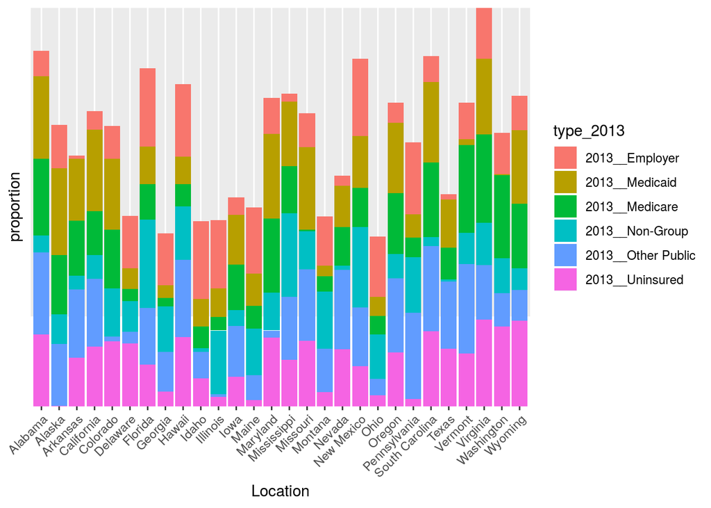

```r
coverage2 %>%
  select(1:7) %>%
  filter(Location!="United States") %>%
  gather("type_2013","amount", -Location) %>%
  group_by(type_2013) %>%
  ggplot(aes(x=Location,y=amount))+
  geom_bar(aes(fill=type_2013),stat="identity", position = "stack")+
  theme(axis.text.x=element_text(angle=45,hjust=1,vjust=1))+
  theme(axis.text.y=element_blank(),axis.ticks.y=element_blank())+
  ylab("proportion")
```

Now, I want to see how the coverage changed from 2013 to 2016 in Illinois.

```r
cov_illinois<-coverage2 %>%
  filter(Location=="Illinois") %>%
  gather("types","amount", -Location) %>%
  filter(!grepl("Total",types)) %>%
  select(-c(Location))

#sp_illinois<-spend %>%
#  filter(Location=="Illinois")
```

```r
cov_illinois[,"years"]<- c(rep("2013",6),rep("2014",6),rep("2015",6),rep("2016",6))
```

```r
#which(grepl("Employer",cov_illinois$types))
cov_illinois$types[which(grepl("Employer",cov_illinois$types))]<-"Employer"
cov_illinois$types[which(grepl("Non-Group",cov_illinois$types))]<-"Non-Group"
cov_illinois$types[which(grepl("Medicaid",cov_illinois$types))]<-"Medicaid"
cov_illinois$types[which(grepl("Medicare",cov_illinois$types))]<-"Medicare"
cov_illinois$types[which(grepl("Other Public",cov_illinois$types))]<-"Other Public"
cov_illinois$types[which(grepl("Uninsured",cov_illinois$types))]<-"Uninsured"
```

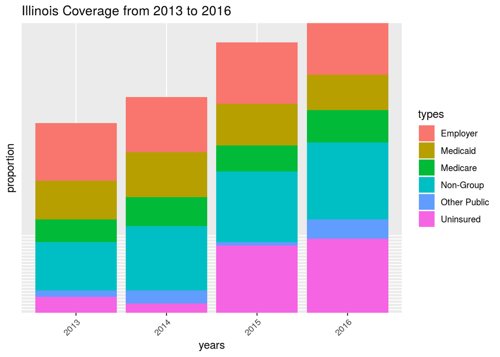

```r
cov_illinois %>%
  group_by(years) %>%
  ggplot(aes(x=years,y=amount))+
  geom_bar(aes(fill=types),stat="identity", position = "stack")+
  theme(axis.text.x=element_text(angle=45,hjust=1,vjust=1))+
  theme(axis.text.y=element_blank(),axis.ticks.y=element_blank())+
  ylab("proportion")+ggtitle("Illinois Coverage from 2013 to 2016")
```

```r
spend2013_14<-spend %>%
  select(Location,`2013__Total Health Spending`, `2014__Total Health Spending`) %>% filter(Location=="United States")
```

```r
data2013_14<-coverage %>%
  select(Location,`2013__Total`, `2014__Total`) %>%
  filter(Location=="United States") %>%
  full_join(spend2013_14, by="Location") %>%
  select(-c("Location")) %>%
  gather("coverage_and_spend","amount") %>%
  ggplot(aes(x="coverage_and_spend", y="amount", fill="coverage_and_spend") )+geom_bar(stat="identity")
```